# Using Turnstile Data To Forecast Student Worker Staffing

Chad Madding, Shane Weinstock

April 11, 2020

### Clients

This report is being prepared for the management of the Dedman Center for Lifetime Sports at Southern Methodist University.

### Directive

We have been tasked with providing general usage of the facilities in the form of entry data. The main goal will be to use ID swipes as a response variable to assist in hiring patters for the facilities’ student staff. It is the goal of the report to assist in the spotting of trends and thus correctly identify staffing needs. Forecasting and general knowledge about building usage will also assist with budgeting needs.

### Data

The data provided to us has been collected from three turnstiles at the Dedman Center for Lifetime Sports on the campus of Southern Methodist University. The data set is a record of the time of swipe, the turnstile used, and an anonymized student ID number. The data was collected from January 2nd, 2019 through March 11th, 2020, and consists of 414,156 entries. Entry and error swipes are included in the data. It should be noted that the turnstiles are only used to enter the facility, and no swipe is required to exit the building. We have also collected hourly weather data from NOAA for the same period to assist in forecasting.

To get ready for merging the temperature data we needed to clean up the hours in the SMU data.

```r
#Group hours
SMUSwipe$TempTime <- format(SMUSwipe$LDT,"%Y-%m-%d")
SMUSwipe$Hour <-ifelse(SMUSwipe$Hour <= '04','04',
                      ifelse(SMUSwipe$Hour <= '08','08',
                      ifelse(SMUSwipe$Hour <=  12, 12,
                      ifelse(SMUSwipe$Hour <=  16, 16,
                      ifelse(SMUSwipe$Hour <=  20, 20,
                      ifelse(SMUSwipe$Hour <=  24, 24))))))
SMUSwipe$TempTime<-paste(SMUSwipe$TempTime, SMUSwipe$Hour, sep=" ")
```

We made the data the same format for the weather data as well as in the SMU information.

```r
#Create a TempTime in HourlyWeather to merge Temperature data
HourlyWeather$TempTime <- format(HourlyWeather$DATE,"%Y-%m-%d")
HourlyWeather$Hour <- format(HourlyWeather$DATE,"%H")

HourlyWeather$Hour <-ifelse(HourlyWeather$Hour <= '04','04',
                      ifelse(HourlyWeather$Hour <= '08','08',
                      ifelse(HourlyWeather$Hour <=  12, 12,
                      ifelse(HourlyWeather$Hour <=  16, 16,
                      ifelse(HourlyWeather$Hour <=  20, 20,
                      ifelse(HourlyWeather$Hour <=  24, 24))))))
HourlyWeather$TempTime<-paste(HourlyWeather$TempTime, HourlyWeather$Hour, sep=" ")
#Recreate the Hour data
SMUSwipe$Hour <- format(SMUSwipe$LDT,"%H")
```

Here we are merging on TempTime to pull in hourly weather data

```r
#Merge on TempTime to pull in hourly weather data
SMUSwipe = merge(SMUSwipe, HourlyWeather, by.x='TempTime', by.y='TempTime',all.x = TRUE, all.y = TRUE)
#Remove dup after the left join
SMUSwipe = distinct(SMUSwipe, LDT, .keep_all = TRUE)
SMUSwipe = SMUSwipe[which(!is.na(SMUSwipe$`LDT`)),]

#sum(is.na(SMUSwipe$HourlyDryBulbTemperature))

#Fill in NA's from Temperature data with number close to the mean
SMUSwipe$HourlyDryBulbTemperature[is.na(SMUSwipe$HourlyDryBulbTemperature)] <- 65
SMUSwipe$HourlyAltimeterSetting[is.na(SMUSwipe$HourlyAltimeterSetting)] <- 30
SMUSwipe$HourlyDewPointTemperature[is.na(SMUSwipe$HourlyDewPointTemperature)] <- 49
SMUSwipe$HourlyRelativeHumidity[is.na(SMUSwipe$HourlyRelativeHumidity)] <- 58
SMUSwipe$HourlyWindSpeed[is.na(SMUSwipe$HourlyWindSpeed)] <- 0

#Renaming some information for ease of use
SMUSwipe$Temperature <- SMUSwipe$HourlyDryBulbTemperature
SMUSwipe$Hour <- SMUSwipe$Hour.x

#Dropping some data we no longer need
drop <- c("Message Type","Hour.x","Hour.y", "TempTime", "DATE", "HourlyPressureChange", "HourlyPressureTendency", "HourlySeaLevelPressure", "HourlyWetBulbTemperature", "HourlyDryBulbTemperature")
SMUSwipe = SMUSwipe[,!(names(SMUSwipe) %in% drop)]

#Export the dataset
write.csv(SMUSwipe,"SMUSwipe.csv", row.names = FALSE)
```

Create and export datasets for time series studies

```r
#Read in the data
SMU = read.csv('SMUSwipe.csv',header = TRUE)
#Look at the top of the data
head(SMU)
```

```
##                   LDT  ID. Secondary.Object.Name     Time       Day       Date
## 1 2019-01-02 07:14:08 1751        DEDM (101.2LB) 07:14:08 Wednesday 2019-01-02
## 2 2019-01-02 07:20:53 6472        DEDM (101.2LB) 07:20:53 Wednesday 2019-01-02
## 3 2019-01-02 07:11:36 4341        DEDM (101.3LB) 07:11:36 Wednesday 2019-01-02
## 4 2019-01-02 06:16:37  247        DEDM (101.3LB) 06:16:37 Wednesday 2019-01-02
## 5 2019-01-02 07:08:26 1752        DEDM (101.2LB) 07:08:26 Wednesday 2019-01-02
## 6 2019-01-02 07:08:32 2515        DEDM (101.3LB) 07:08:32 Wednesday 2019-01-02
##           Hours   Month HourlyAltimeterSetting HourlyDewPointTemperature
## 1 2019-01-02 07 2019-01                  30.23                        30
## 2 2019-01-02 07 2019-01                  30.23                        30
## 3 2019-01-02 07 2019-01                  30.23                        30
## 4 2019-01-02 06 2019-01                  30.23                        30
## 5 2019-01-02 07 2019-01                  30.23                        30
## 6 2019-01-02 07 2019-01                  30.23                        30
##   HourlyPrecipitation HourlyPresentWeatherType HourlyRelativeHumidity
```

[output cut: 20 more lines]

```r
#Dropping some data we no longer need
drop <- c("ID.", "interval_15", "Minutes_15","Time")
SMU = SMU[,!(names(SMU) %in% drop)]

SMU$Week<-paste(SMU$Month, SMU$Day, sep=" ")

#Renaming some information for ease of use
#SMUSwipe$Temperature <- SMUSwipe$HourlyDryBulbTemperature
#SMUSwipe$Hour <- SMUSwipe$Hour.x

colnames(SMU)[2] = "Turnstile"

SMU$Date <- as.Date(SMU$LDT)

# Extract day of the week (Saturday = 6)
SMU$Week_Day <- as.numeric(format(format.Date(SMU$LDT,"%w")))

# Adjust end-of-week date (first saturday from the original Date)
SMU$End_of_Week <- SMU$Date + (6 - SMU$Week_Day)

HourSwipes = dplyr::count(SMU,Hours)
DaySwipes = dplyr::count(SMU,Date)
WeekSwipes = dplyr::count(SMU,End_of_Week)
MonthSwipes = dplyr::count(SMU,Month)

HourSwipesTemp = merge(HourSwipes,SMU, by='Hours')
HourSwipesTemp = distinct(HourSwipesTemp, Hours, .keep_all = TRUE)

DaySwipesTemp = merge(DaySwipes,SMU, by='Date')
DaySwipesTemp = distinct(DaySwipesTemp, Date, .keep_all = TRUE)
# Aggregate over Date and Temperature
DaySwipesTemp$DayTemperature = aggregate(Temperature~Date, FUN=mean, data=SMU, na.rm=TRUE)
DaySwipesTemp = DaySwipesTemp[,!(names(DaySwipesTemp) %in% 'Temperature')]

WeekSwipesTemp = merge(WeekSwipes,SMU, by='End_of_Week')
WeekSwipesTemp = distinct(DaySwipesTemp, End_of_Week, .keep_all = TRUE)
# Aggregate over week and Temperature
WeekSwipesTemp$WeekTemperature = aggregate(Temperature~End_of_Week, FUN=mean, data=SMU, na.rm=TRUE)
WeekSwipesTemp = WeekSwipesTemp[,!(names(WeekSwipesTemp) %in% 'Temperature')]

MonthSwipesTemp = merge(MonthSwipes,SMU, by='Month')
MonthSwipesTemp = distinct(MonthSwipesTemp, Month, .keep_all = TRUE)
# Aggregate over week and Temperature
MonthSwipesTemp$MonthTemperature = aggregate(Temperature~Month, FUN=mean, data=SMU, na.rm=TRUE)
MonthSwipesTemp = MonthSwipesTemp[,!(names(MonthSwipesTemp) %in% 'Temperature')]

#Change n to IDSwipes
colnames(HourSwipesTemp)[2] = "IDSwipes"
colnames(DaySwipesTemp)[2] = "IDSwipes"
colnames(WeekSwipesTemp)[2] = "IDSwipes"
colnames(MonthSwipesTemp)[2] = "IDSwipes"

#Dropping some data we no longer need
drop <- c("LDT", "Minutes", "Week", "Turnstile")
HourSwipesTemp = HourSwipesTemp[,!(names(HourSwipesTemp) %in% drop)]
DaySwipesTemp = DaySwipesTemp[,!(names(DaySwipesTemp) %in% drop)]
WeekSwipesTemp = WeekSwipesTemp[,!(names(WeekSwipesTemp) %in% drop)]
MonthSwipesTemp = MonthSwipesTemp[,!(names(MonthSwipesTemp) %in% drop)]

#Export the dataset
write.csv(HourSwipesTemp,"DedmanHourlySwipe.csv", row.names = FALSE)
write.csv(DaySwipesTemp,"DedmanDailySwipe.csv", row.names = FALSE)
write.csv(WeekSwipesTemp,"DedmanWeeklySwipe.csv", row.names = FALSE)
write.csv(MonthSwipesTemp,"DedmanMonthlySwipe.csv", row.names = FALSE)
```

We now have a data set with weather data along with card swipes.

```r
head(SMUSwipe)
```

```
##                   LDT  ID# Secondary Object Name     Time       Day       Date
## 2 2019-01-02 07:14:08 1751        DEDM (101.2LB) 07:14:08 Wednesday 2019-01-02
## 3 2019-01-02 07:20:53 6472        DEDM (101.2LB) 07:20:53 Wednesday 2019-01-02
## 4 2019-01-02 07:11:36 4341        DEDM (101.3LB) 07:11:36 Wednesday 2019-01-02
## 5 2019-01-02 06:16:37  247        DEDM (101.3LB) 06:16:37 Wednesday 2019-01-02
## 6 2019-01-02 07:08:26 1752        DEDM (101.2LB) 07:08:26 Wednesday 2019-01-02
## 7 2019-01-02 07:08:32 2515        DEDM (101.3LB) 07:08:32 Wednesday 2019-01-02
##           Hours   Month HourlyAltimeterSetting HourlyDewPointTemperature
## 2 2019-01-02 07 2019-01                  30.23                        30
## 3 2019-01-02 07 2019-01                  30.23                        30
## 4 2019-01-02 07 2019-01                  30.23                        30
## 5 2019-01-02 06 2019-01                  30.23                        30
## 6 2019-01-02 07 2019-01                  30.23                        30
## 7 2019-01-02 07 2019-01                  30.23                        30
##   HourlyPrecipitation HourlyPresentWeatherType HourlyRelativeHumidity
```

[output cut: 20 more lines]

**Hourly Totals:**

In helping access the staffing needs we wanted to get a snapshot of the general usage of the facilities.

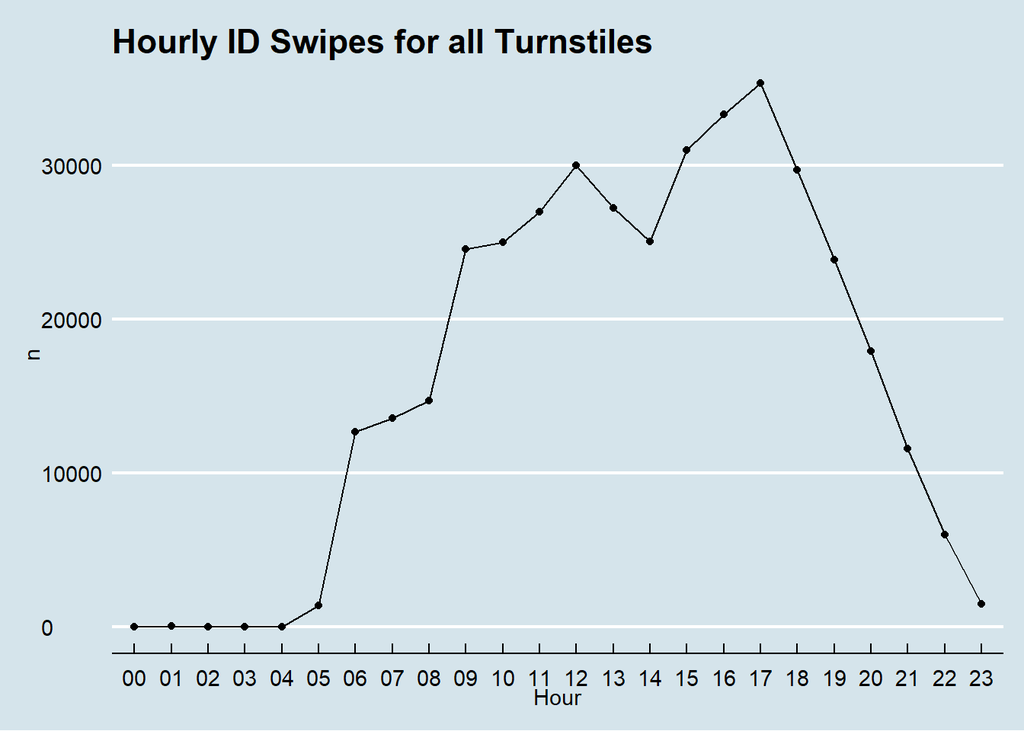

```r
#Group all badge swipes by the hour

hourplot = dplyr::count(SMUSwipe,Hour)

hourplot %>%
  ggplot(aes(x=Hour,y=n, group=1))+
  geom_line()+
  geom_point()+
  theme_economist()+
  scale_colour_economist()+
  ggtitle('Hourly ID Swipes for all Turnstiles')
```

What are the Daily ID Swipes for all Turnstiles?

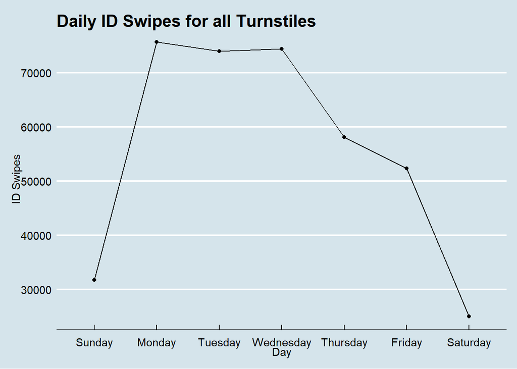

```r
dayCount=dplyr::count(SMUSwipe, Day)
dayCount$Day <- factor(dayCount$Day, levels= c("Sunday", "Monday",
    "Tuesday", "Wednesday", "Thursday", "Friday", "Saturday"))

dayCount=dayCount[order(dayCount$Day), ]

dayCount %>%
  ggplot(aes(x=Day,y=n, group=1))+
  geom_line()+
  geom_point()+
  theme_economist()+
  scale_colour_economist()+
  theme_economist()+
  ggtitle('Daily ID Swipes for all Turnstiles')+
  ylab('ID Swipes')
```

Top Days look to be Monday, Tuesday and Wednesday.

Look at turnstile information.  
Create individual turnstile data

```r
#Create a dataset for each turnstyle
SMUSwipeTurn1 = SMUSwipe[SMUSwipe[,3]=="DEDM (101.1LB)",]
SMUSwipeTurn2 = SMUSwipe[SMUSwipe[,3]=="DEDM (101.2LB)",]
SMUSwipeTurn3 = SMUSwipe[SMUSwipe[,3]=="DEDM (101.3LB)",]
```

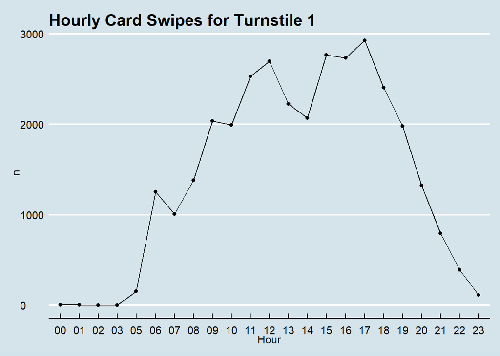

```r
df = dplyr::count(SMUSwipeTurn3, Hours)

HTurn1 = dplyr::count(SMUSwipeTurn1, Hour)
HTurn1 %>%
  ggplot(aes(x=Hour,y=n, group=1))+
  geom_line()+
  geom_point()+
  theme_economist()+
  scale_colour_economist()+
  ggtitle('Hourly Card Swipes for Turnstile 1')
```

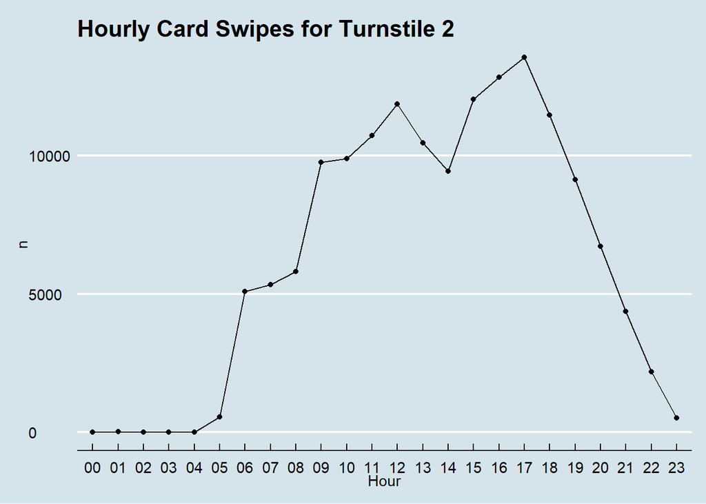

```r
HTurn2 = dplyr::count(SMUSwipeTurn2, Hour)
HTurn2 %>%
  ggplot(aes(x=Hour,y=n, group=1))+
  geom_line()+
  geom_point()+
  theme_economist()+
  scale_colour_economist()+
  ggtitle('Hourly Card Swipes for Turnstile 2')
```

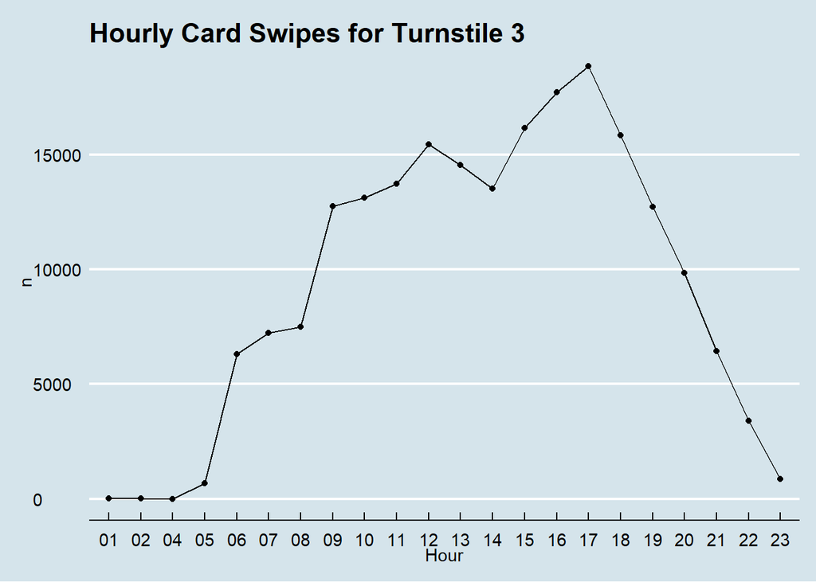

```r
HTurn3 = dplyr::count(SMUSwipeTurn3, Hour)
HTurn3 %>%
  ggplot(aes(x=Hour,y=n, group=1))+
  geom_line()+
  geom_point()+
  theme_economist()+
  scale_colour_economist()+
  ggtitle('Hourly Card Swipes for Turnstile 3')
```

Looks like turnstile 3 gets used more than the others but the pattern of usage looks the same across each.

This data is anamonized but we can still see who are some of the top users.

```r
#This will count up the times users swiped in.
IDCount = dplyr::count(SMUSwipe, `ID#`)
#Print off the top 10 users ordering nuency in decending order
head(IDCount[order(IDCount$n, decreasing = TRUE),],10)
```

```
## # A tibble: 10 x 2
##    `ID#`     n
##    <dbl> <int>
##  1  1445   429
##  2  1168   413
##  3  1429   390
##  4  1469   369
##  5  1140   361
##  6   912   354
##  7  1778   349
##  8   104   339
##  9   152   338
## 10   214   335
```

Look at some user data.

```r
#Breakdown user numbers
summary(IDCount$n)
```

```
##    Min. 1st Qu.  Median    Mean 3rd Qu.    Max.
##    1.00    7.00   21.00   35.99   48.00  429.00
```

```r
#how many users
dplyr::count(IDCount)
```

```
## # A tibble: 1 x 1
##       n
##   <int>
## 1 10873
```

#### Stationarity

**To address stationarity we will first visualize the daily count data.**

After reading in the data we will convert it to a time series object.

```r
#Read in the daily data set
DedmanDailySwipe <- read_csv("DedmanDailySwipe.csv")
```

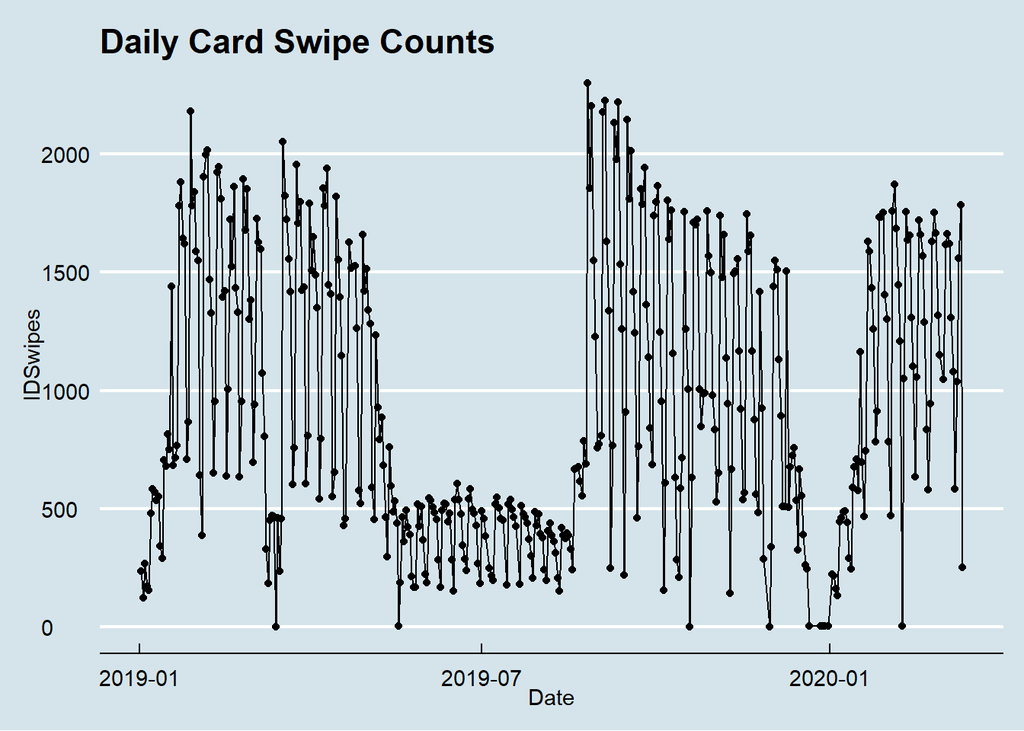

```r
#Conver the IDSwipes data to Time Series
DedmanDailyTS = ts(DedmanDailySwipe$IDSwipes, start = c(2019,2), frequency = 365)
head(DedmanDailyTS)
DedmanDailyTS

# Test for Conditions we Plot the daily data
#The plotts will give a large view of all the data
DedmanDailySwipe %>%
  ggplot(aes(x=Date,y=IDSwipes, group=1))+
  geom_line()+
  geom_point()+
  theme_economist()+
  scale_colour_economist()+
  ggtitle('Daily Card Swipe Counts')
```

Looking at the data we see dips in the usage during Spring Break, Summer and Winter Break. This is typical for the area the data comes from.

We can check to see if the mean is constant by comparing the overall mean of the data set to a rolling mean.

```r
#To to check for a constant mean
#Rolling Mean vs. the data set mean
DedmanRollMean = mean(rollmean(DedmanDailyTS, 7))
DedmanRollMean
```

```
## [1] 933.7449
```

```r
DedmanMean = mean(DedmanDailyTS)
DedmanMean
```

```
## [1] 929.4014
```

```r
#Weekly Rolling Mean = 933.7 Mean = 929.4
```

A weekly rolling mean turns out to be 934 which is very close to the overall mean of 929. One more bit of evidence pointing to the mean not being dependent on time.

```r
#plotts.sample will give us an over view of
TurnPlotDaily=plotts.sample.wge(DedmanDailyTS)
```

[output not shown]

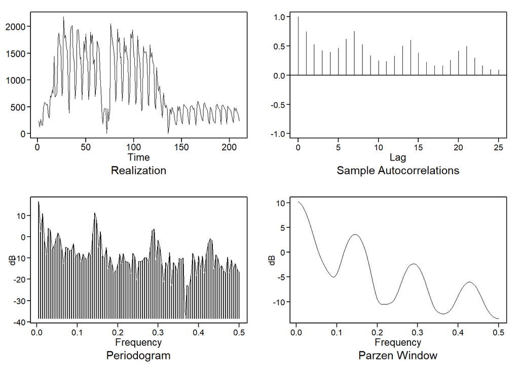

```
## $autplt
##  [1] 1.00000000 0.74451789 0.52525971 0.42015587 0.39303809 0.45837190
##  [7] 0.62292057 0.75074183 0.52449934 0.33388972 0.25038011 0.23774173
## [13] 0.32923524 0.50322599 0.60032808 0.38495381 0.22141524 0.16369944
## [19] 0.16127432 0.25922502 0.41573139 0.49334257 0.29696482 0.16689614
## [25] 0.09779387 0.09017726
##
## $freq
##   [1] 0.004761905 0.009523810 0.014285714 0.019047619 0.023809524 0.028571429
##   [7] 0.033333333 0.038095238 0.042857143 0.047619048 0.052380952 0.057142857
##  [13] 0.061904762 0.066666667 0.071428571 0.076190476 0.080952381 0.085714286
##  [19] 0.090476190 0.095238095 0.100000000 0.104761905 0.109523810 0.114285714
##  [25] 0.119047619 0.123809524 0.128571429 0.133333333 0.138095238 0.142857143
##  [31] 0.147619048 0.152380952 0.157142857 0.161904762 0.166666667 0.171428571
##  [37] 0.176190476 0.180952381 0.185714286 0.190476190 0.195238095 0.200000000
```

[output cut: 54 more lines]

```r
plotts.sample.wge(head(DedmanDailyTS,length(DedmanDailyTS)/2))
```

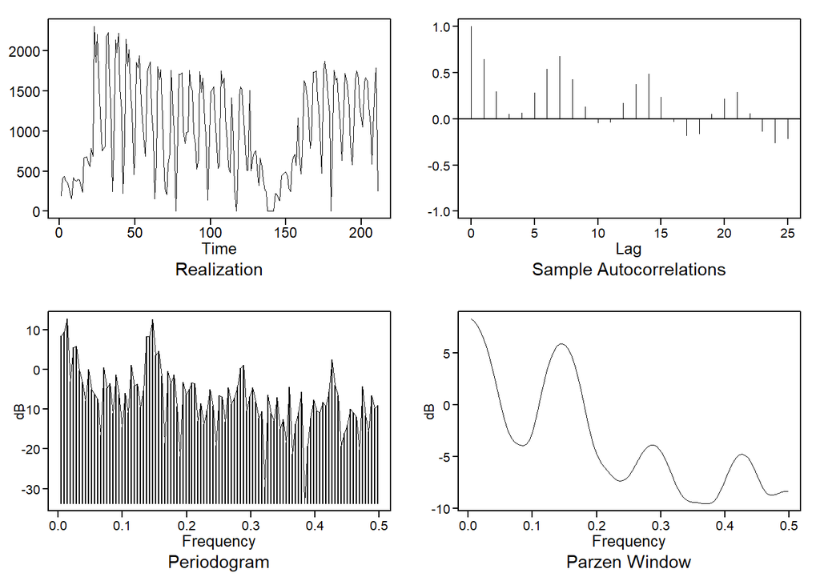

```
## $autplt
##  [1]  1.00000000  0.64485282  0.29821507  0.05495161  0.06652498  0.28461676
##  [7]  0.54222054  0.67862574  0.42698808  0.13449809 -0.04287031 -0.03196987
## [13]  0.17370306  0.37619473  0.48812016  0.23558666 -0.02481635 -0.18116831
## [19] -0.15780418  0.05112644  0.21633302  0.29287205  0.05602116 -0.13453557
## [25] -0.25612233 -0.20994003
##
## $freq
##   [1] 0.004739336 0.009478673 0.014218009 0.018957346 0.023696682 0.028436019
##   [7] 0.033175355 0.037914692 0.042654028 0.047393365 0.052132701 0.056872038
##  [13] 0.061611374 0.066350711 0.071090047 0.075829384 0.080568720 0.085308057
##  [19] 0.090047393 0.094786730 0.099526066 0.104265403 0.109004739 0.113744076
##  [25] 0.118483412 0.123222749 0.127962085 0.132701422 0.137440758 0.142180095
##  [31] 0.146919431 0.151658768 0.156398104 0.161137441 0.165876777 0.170616114
##  [37] 0.175355450 0.180094787 0.184834123 0.189573460 0.194312796 0.199052133
```

[output cut: 51 more lines]

```r
plotts.sample.wge(tail(DedmanDailyTS,length(DedmanDailyTS)/2))
```

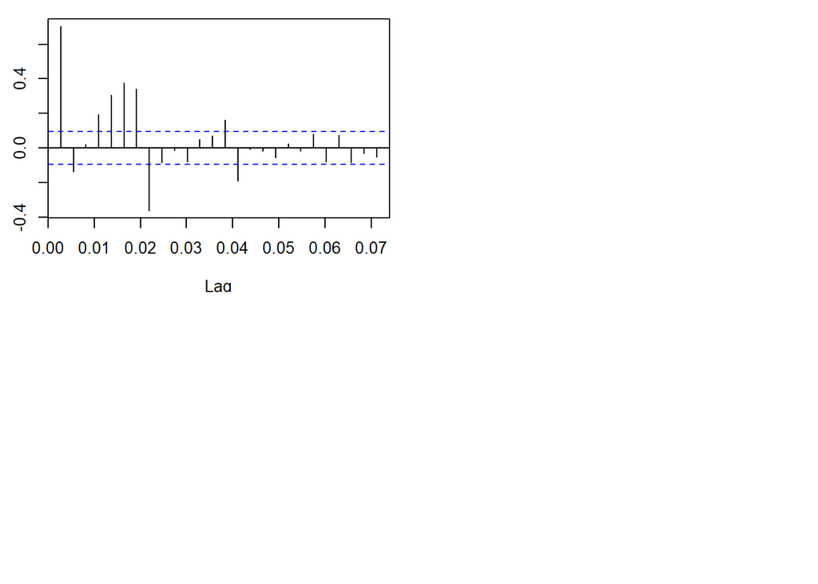

```r
pacf(DedmanDailyTS)
```

#### Seasonal Model

Lets see what a Seasonal Model might look like

Look at the data again.

```r
plotts.sample.wge(DedmanDailyTS)
```

[output not shown]

```r
#Factor tables
factDedmanDaily=est.ar.wge(DedmanDailyTS,p=7,type='burg')
```

```
##
## Coefficients of Original polynomial:
## 0.4922 -0.0805 -0.0538 0.0019 0.0566 0.1608 0.3495
##
## Factor                 Roots                Abs Recip    System Freq
## 1-0.9823B              1.0181               0.9823       0.0000
## 1-1.2008B+0.9038B^2    0.6643+-0.8156i      0.9507       0.1412
## 1+0.3128B+0.6680B^2   -0.2342+-1.2009i      0.8173       0.2806
## 1+1.3780B+0.5894B^2   -1.1691+-0.5744i      0.7677       0.4273
##
##
```

```r
factor.wge(c(0,0,0,0,0,0,1)) #(1-B^7)
```

```
##
## Coefficients of Original polynomial:
## 0.0000 0.0000 0.0000 0.0000 0.0000 0.0000 1.0000
##
## Factor                 Roots                Abs Recip    System Freq
## 1-1.0000B              1.0000               1.0000       0.0000
## 1+0.4450B+1.0000B^2   -0.2225+-0.9749i      1.0000       0.2857
## 1-1.2470B+1.0000B^2    0.6235+-0.7818i      1.0000       0.1429
## 1+1.8019B+1.0000B^2   -0.9010+-0.4339i      1.0000       0.4286
##
##
```

Use artrans.wge() to get y. This is to remove the seasonality in the data.

```r
#Use artrans.wge() to get y. This is to remove the seasonality in the data.
#In this data we are checking for a weekley trend (7).
y = artrans.wge(DedmanDailyTS,phi.tr=c(0,0,0,0,0,0,1))
```

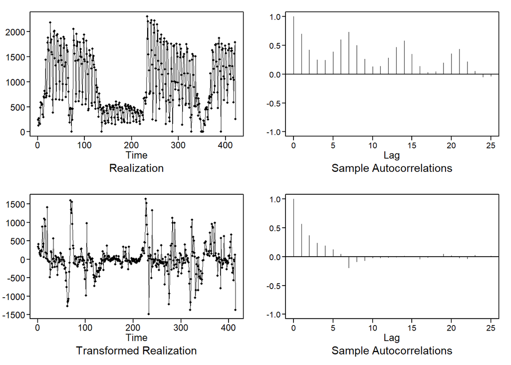

```r
# y is the transformed data
#aic5.wge(y,p=0:15,q=0:9,type='aic') #AIC picked a ARMA(1,7)=11.48657
```

Based on the decision to fit an ARMA(1,7) model, we use the est.ar.wge command to obtain Maximum Likelihood (ML) estimates.

```r
DedmanDailyTS.est17=est.arma.wge(y,p=1, q=7)
```

```
##
## Coefficients of Original polynomial:
## 0.4765
##
## Factor                 Roots                Abs Recip    System Freq
## 1-0.4765B              2.0989               0.4765       0.0000
##
##
```

```r
DedmanDailyTS.est17$phi
```

```
## [1] 0.4764507
```

```r
DedmanDailyTS.est17$theta
```

```
## [1] -0.16467422 -0.07555476 -0.09055213 -0.08431572 -0.14302341 -0.24635376
## [7]  0.47057250
```

```r
DedmanDailyTS.est17$avar
```

```
## [1] 93255.27
```

```r
mean(DedmanDailyTS)
```

```
## [1] 929.4014
```

#### Final Seasonal Model

$$(1-B^{7})(1-0.476B)(X_t-929.4)=(1+0.165B+0.076B^2+0.091B^3+0.084B^4+0.143B^5+0.246B^6-0.471B^7)a_t\ \sigma^2_a=93255.27$$

```r
seasonFore=fore.aruma.wge(DedmanDailyTS,phi=c(DedmanDailyTS.est17$phi),theta=c(DedmanDailyTS.est17$theta),s=7,n.ahead=14,limits=F)
```

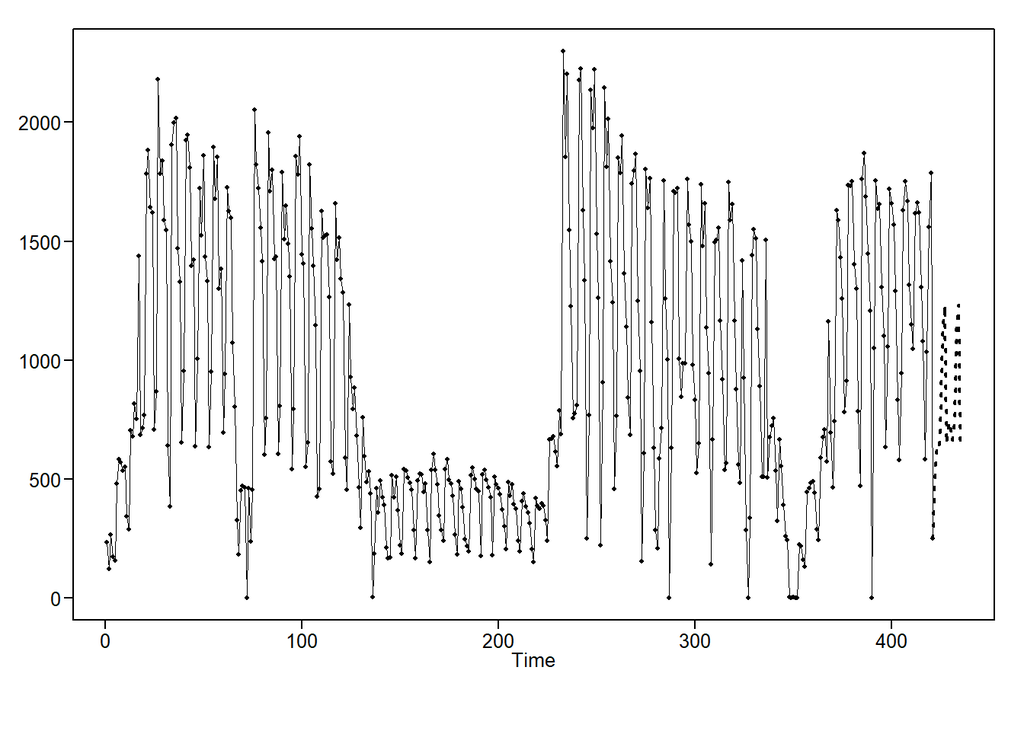

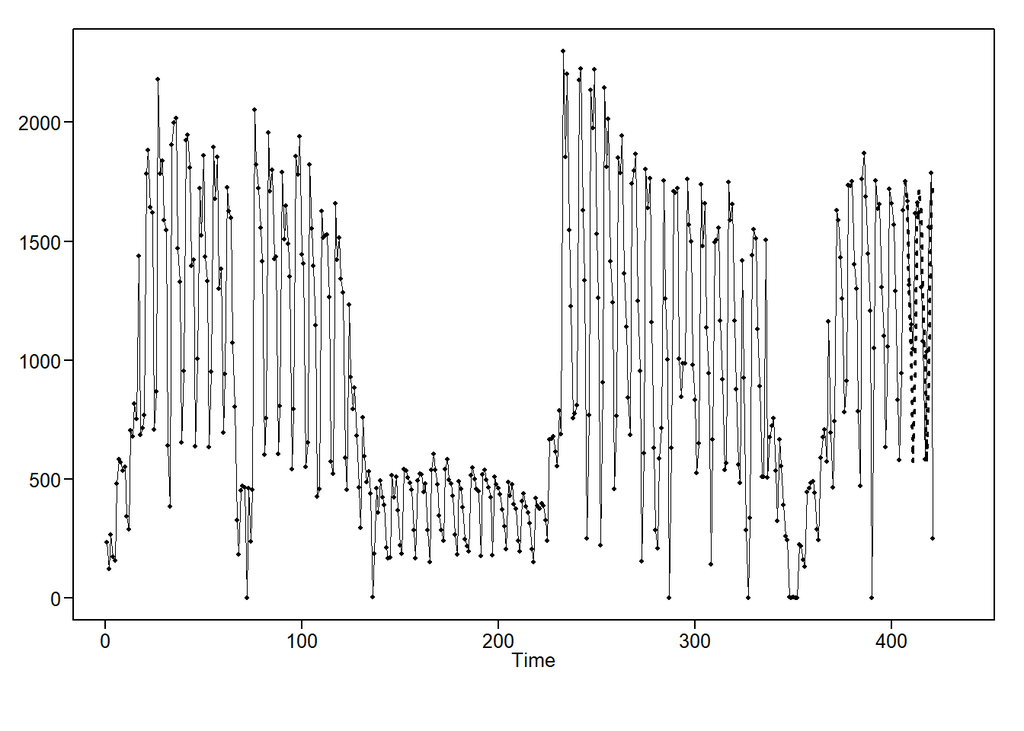

```r
seasonFore$f

fore.aruma.wge(DedmanDailyTS,phi=c(DedmanDailyTS.est17$phi),theta=c(DedmanDailyTS.est17$theta),s=7,n.ahead=14,plot=T,lastn=T,limits=F)
```

```r
p=1;q=7;s=7
x=DedmanDailyTS
es=tswge::est.arma.wge(x,p=p,q=q)
```

```
##
## Coefficients of Original polynomial:
## 0.7107
##
## Factor                 Roots                Abs Recip    System Freq
## 1-0.7107B              1.4071               0.7107       0.0000
##
##
```

```r
ase = function(f,x){mean((f - tail(x,length(f)))^2)}
m = tswge::fore.aruma.wge(x,phi = es$phi,theta = es$theta,s=s,n.ahead = 14,lastn = T, limits = F)
```

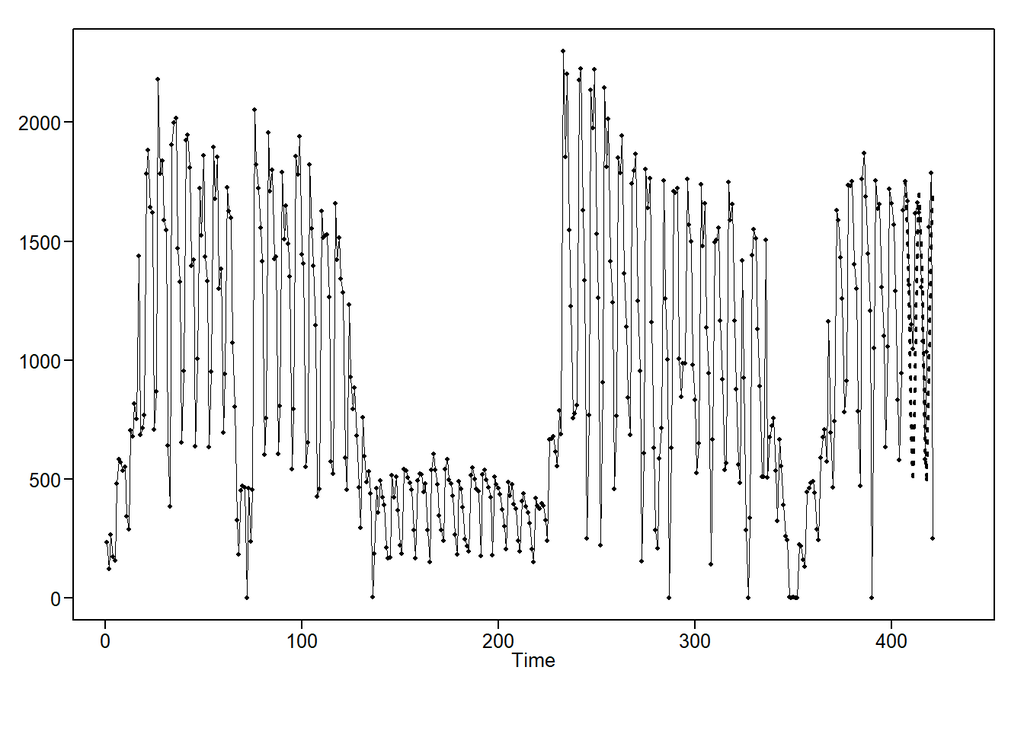

```r
ase = ase(m$f,x)
message("ASE is: ",ase)
```

```
## ASE is: 286078.657261366
```

```r
ASE_Season=ase
```

#### Neural Network with IDSwipes as the Response Variable.

```r
#We will forcast out two weeks
SMUForcast = 14

#Read in the data
SMU = read.csv('DedmanDailySwipe.csv',header = TRUE)
#get the total rows
CMRows = nrow(SMU)
#To look at just the last x number of days change this to a real number
SMUDays= CMRows

SMU = SMU[((CMRows-SMUDays)+1):(CMRows),]
#Look at the top of the data
head(SMU)
```

```
##         Date IDSwipes       Day         Hours   Month HourlyAltimeterSetting
## 1 2019-01-02      235 Wednesday 2019-01-02 07 2019-01                  30.23
## 2 2019-01-03      123  Thursday 2019-01-03 07 2019-01                  30.07
## 3 2019-01-04      267    Friday 2019-01-04 04 2019-01                  29.94
## 4 2019-01-05      172  Saturday 2019-01-05 07 2019-01                  30.10
## 5 2019-01-06      156    Sunday 2019-01-06 12 2019-01                  30.10
## 6 2019-01-07      480    Monday 2019-01-07 08 2019-01                  30.01
##   HourlyDewPointTemperature HourlyPrecipitation HourlyPresentWeatherType
## 1                        30                  NA           -RA:02 |RA |RA
## 2                        36                  NA           -RA:02 |RA |RA
## 3                        33                  NA                     <NA>
## 4                        34                  NA                     <NA>
## 5                        43                  NA                     <NA>
## 6                        59                  NA                     <NA>
##   HourlyRelativeHumidity HourlySkyConditions HourlyStationPressure
```

[output cut: 20 more lines]

```r
#ggpairs(SMU[c(2,3,6,7,10,12,16,18,21)])

#get the total rows
CMRows = nrow(SMU)

plotts.sample.wge(SMU$IDSwipes)
```

```
## $autplt
##  [1]  1.00000000  0.70215951  0.42324532  0.25110163  0.24537802  0.38890810
##  [7]  0.59940311  0.73274869  0.50042359  0.26253004  0.13417670  0.13517610
## [13]  0.28431957  0.47112224  0.57721389  0.34840851  0.13815428  0.03215917
## [19]  0.04316582  0.19659812  0.35731162  0.43329390  0.21962520  0.05292005
## [25] -0.04562156 -0.03182862
##
## $freq
##   [1] 0.002375297 0.004750594 0.007125891 0.009501188 0.011876485 0.014251781
##   [7] 0.016627078 0.019002375 0.021377672 0.023752969 0.026128266 0.028503563
##  [13] 0.030878860 0.033254157 0.035629454 0.038004751 0.040380048 0.042755344
##  [19] 0.045130641 0.047505938 0.049881235 0.052256532 0.054631829 0.057007126
##  [25] 0.059382423 0.061757720 0.064133017 0.066508314 0.068883610 0.071258907
##  [31] 0.073634204 0.076009501 0.078384798 0.080760095 0.083135392 0.085510689
##  [37] 0.087885986 0.090261283 0.092636580 0.095011876 0.097387173 0.099762470
```

[output cut: 102 more lines]

```r
SMUsmall = SMU[1:(CMRows-SMUForcast),]

SMUsmallDF = data.frame(Temperature = ts(SMUsmall$DayTemperature.Temperature), Humidity = ts(SMUsmall$HourlyRelativeHumidity),Day = ts(SMUsmall$Week_Day), DewPoint = ts(SMUsmall$HourlyDewPointTemperature))

SMUsmallDF <- na.omit(SMUsmallDF)

fit.mlp = mlp(ts(SMUsmall$IDSwipes),reps = 50,comb = "median", xreg = SMUsmallDF)

fit.mlp
```

```
## MLP fit with 5 hidden nodes and 50 repetitions.
## Univariate lags: (1,2,3,4)
## 4 regressors included.
## - Regressor 1 lags: (1)
## - Regressor 2 lags: (1,4)
## - Regressor 3 lags: (1,2,4)
## - Regressor 4 lags: (1,2)
## Forecast combined using the median operator.
## MSE: 23006.9328.
```

```r
plot(fit.mlp)

SMUDF = data.frame(Temperature = ts(SMU$DayTemperature.Temperature), Humidity = ts(SMU$HourlyRelativeHumidity),Day = ts(SMU$Week_Day), DewPoint = ts(SMU$HourlyDewPointTemperature))

fore.mlp = forecast(fit.mlp, h = SMUForcast , xreg = SMUDF)

fore.mlp
```

[output not shown]

```
##     Point Forecast
## 408      1730.2034
## 409      1366.8969
## 410      1263.4322
## 411       603.0450
## 412      1744.6777
## 413      1674.7283
## 414      1805.2004
## 415      1327.0011
## 416      1154.3120
## 417       593.4179
## 418       908.1522
## 419      1781.6018
## 420      1703.4497
## 421      1740.7557
```

```r
plot(fore.mlp)

ASE_SMU_NN = mean((SMU$IDSwipes[((CMRows-SMUForcast)+1):CMRows] - fore.mlp$mean)^2)
ASE_SMU_NN
```

[output not shown]

```
## [1] 183586.8
```

```r
while (!is.null(dev.list()))  dev.off()
par(mfrow = c(2,1))
```

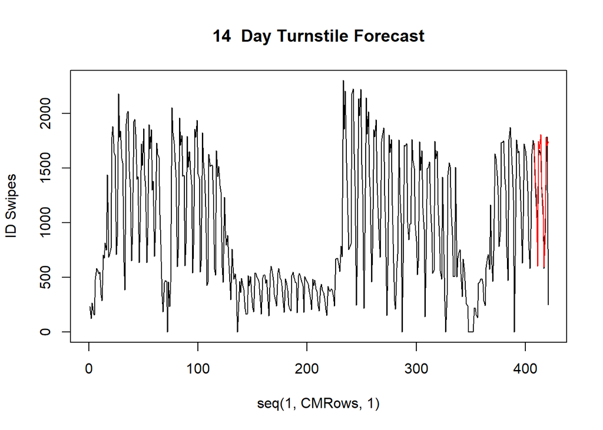

```r
#Plot
plot(seq(1,CMRows,1), SMU$IDSwipes, type = "l",xlim = c(0,CMRows), ylab = "ID Swipes", main = paste(SMUForcast," Day Turnstile Forecast"))
lines(seq(((CMRows-SMUForcast)+1),CMRows,1), fore.mlp$mean, type = "l", col = "red")
```

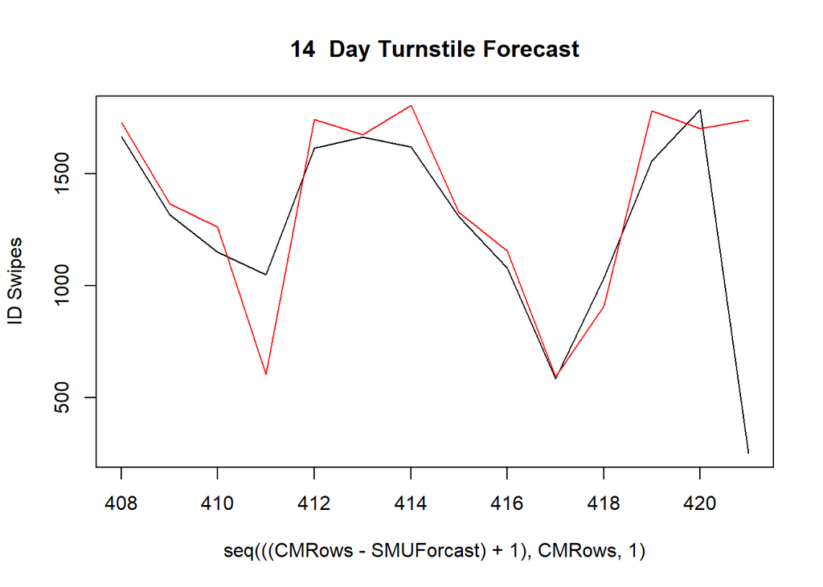

```r
#Plot
plot(seq(((CMRows-SMUForcast)+1),CMRows,1), SMU$IDSwipes[((CMRows-SMUForcast)+1):CMRows], type = "l",xlim = c((CMRows-SMUForcast)+1,CMRows), ylab = "ID Swipes", main = paste(SMUForcast," Day Turnstile Forecast"))
lines(seq(((CMRows-SMUForcast)+1),CMRows,1), fore.mlp$mean, type = "l", col = "red")
```

SMU data NN using the default settings.

```r
fit.mlp = mlp(ts(SMUsmall$IDSwipes))
fit.mlp
```

```
## MLP fit with 5 hidden nodes and 20 repetitions.
## Univariate lags: (1,2,3,4)
## Forecast combined using the median operator.
## MSE: 59179.8921.
```

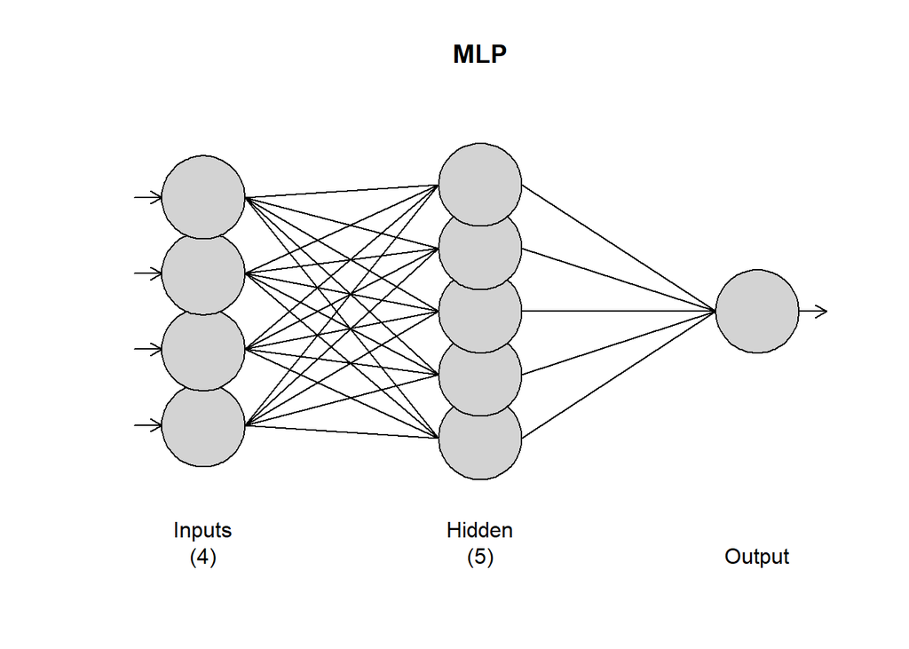

```r
plot(fit.mlp)
```

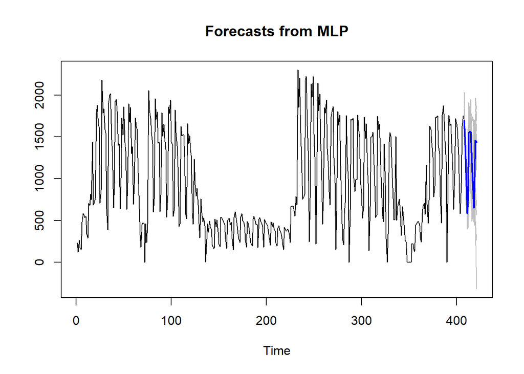

```r
fore.mlp = forecast(fit.mlp, h = 14)
plot(fore.mlp)
```

```r
ASE_SMU_NNid = mean((SMU$IDSwipes[((CMRows-SMUForcast)+1):CMRows] - fore.mlp$mean)^2)
ASE_SMU_NNid
```

```
## [1] 226961.9
```

#### VAR with IDSwipes as the Response Variable.

```r
#VAR
SMForcast = 14
SM = SMU
#get the total rows
SMRows = nrow(SM)
SMsmall = SM[1:(SMRows-SMForcast),]

#VAR Model 3 seasonal with Lag 1 Temp
#SMsmall$temp_1 = dplyr::lag(SMsmall$Temperature,1)

VARselect(cbind(SMsmall$IDSwipes[1:(SMRows-SMForcast)], SMsmall$Temperature[1:(SMRows-SMForcast)], SMsmall$HourlyRelativeHumidity[1:(SMRows-SMForcast)],SMsmall$Day[1:(SMRows-SMForcast)]))
```

```
## $selection
## AIC(n)  HQ(n)  SC(n) FPE(n)
##      7      7      7      7
##
## $criteria
##                   1            2            3            4            5
## AIC(n) 1.874065e+01 1.784780e+01 1.754869e+01 1.725800e+01 1.658284e+01
## HQ(n)  1.878836e+01 1.793128e+01 1.766794e+01 1.741303e+01 1.677365e+01
## SC(n)  1.886108e+01 1.805854e+01 1.784974e+01 1.764937e+01 1.706452e+01
## FPE(n) 1.377094e+08 5.639054e+07 4.181305e+07 3.126691e+07 1.591811e+07
##                   6            7            8            9           10
## AIC(n) 1.624765e+01 1.602847e+01 1.603295e+01 1.606164e+01 1.609089e+01
## HQ(n)  1.647424e+01 1.629083e+01 1.633109e+01 1.639556e+01 1.646058e+01
## SC(n)  1.681965e+01 1.669078e+01 1.678558e+01 1.690459e+01 1.702415e+01
## FPE(n) 1.138575e+07 9.145808e+06 9.188395e+06 9.457722e+06 9.740913e+06
```

```r
VAR_SM = VAR(cbind(SMsmall$IDSwipes[1:(SMRows-SMForcast)], SMsmall$Temperature[1:(SMRows-SMForcast)], SMsmall$HourlyRelativeHumidity[1:(SMRows-SMForcast)],SMsmall$Day[1:(SMRows-SMForcast)]))
```

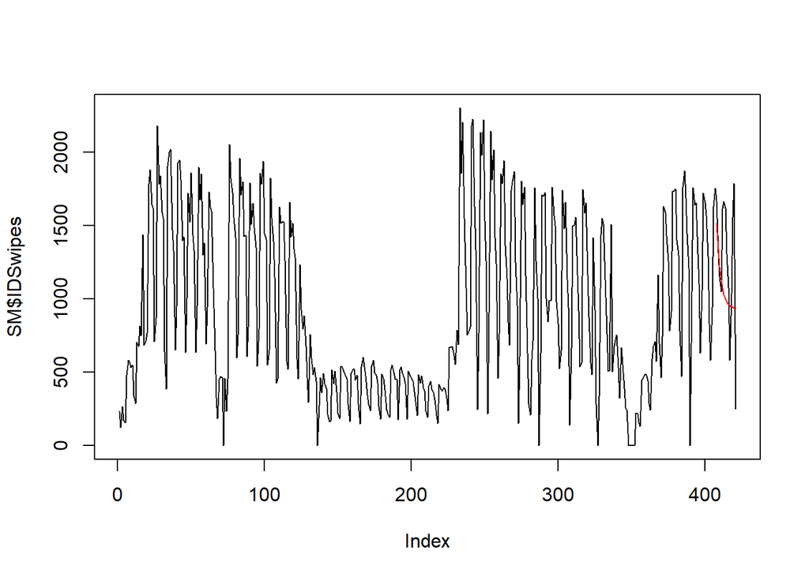

```r
pred = predict(VAR_SM,n.ahead = SMForcast)

#while (!is.null(dev.list()))  dev.off()

plot(SM$IDSwipes, type = "l")
lines(seq((SMRows-SMForcast)+1,SMRows,1),pred$fcst$y1[,1],col = "red")
```

```r
ASE_SMU_VAR = mean((SM$IDSwipes[((SMRows-SMForcast)+1):SMRows] - pred$fcst$y1[1:SMForcast])^2)

ASE_SMU_VAR
```

```
## [1] 210661.4
```